# Análisis de Datos de Viviendas

Presentación de Resultados

JoaquinMa Montero

2025-03-10

# Carga de Datos y Exploración

```r
# Cargar los datos
df <- read.csv("housing.csv", stringsAsFactors = FALSE)

# Mostrar la estructura del dataset para entender sus variables y tipos de datos
str(df)
```

```
## 'data.frame':    20640 obs. of  10 variables:
##  $ longitude         : num  -122 -122 -122 -122 -122 ...
##  $ latitude          : num  37.9 37.9 37.9 37.9 37.9 ...
##  $ housing_median_age: num  41 21 52 52 52 52 52 52 42 52 ...
##  $ total_rooms       : num  880 7099 1467 1274 1627 ...
##  $ total_bedrooms    : num  129 1106 190 235 280 ...
##  $ population        : num  322 2401 496 558 565 ...
##  $ households        : num  126 1138 177 219 259 ...
##  $ median_income     : num  8.33 8.3 7.26 5.64 3.85 ...
##  $ median_house_value: num  452600 358500 352100 341300 342200 ...
##  $ ocean_proximity   : chr  "NEAR BAY" "NEAR BAY" "NEAR BAY" "NEAR BAY" ...
```

*Comentario:* Este dataset contiene información sobre viviendas, con variables numéricas y categóricas. Se revisa la estructura para identificar posibles transformaciones necesarias.

# Procesamiento de Datos

```r
# Imputar valores faltantes en total_bedrooms con la mediana
df$total_bedrooms[is.na(df$total_bedrooms)] <- median(df$total_bedrooms, na.rm = TRUE)

# Convertir ocean_proximity en variable categórica
df$ocean_proximity <- as.factor(df$ocean_proximity)

# Crear nuevas variables derivadas
df$rooms_per_household <- df$total_rooms / df$households
df$bedrooms_per_room <- df$total_bedrooms / df$total_rooms
df$population_per_household <- df$population / df$households
```

*Comentario:* Se imputa la variable `total_bedrooms` con la mediana para evitar la pérdida de información. Se convierten variables categóricas y se crean nuevas variables para representar mejor las características de las viviendas.

# Análisis Estadístico Descriptivo

```r
# Resumen estadístico de las variables numéricas
summary(df)
```

```
##    longitude         latitude     housing_median_age  total_rooms
##  Min.   :-124.3   Min.   :32.54   Min.   : 1.00      Min.   :    2
##  1st Qu.:-121.8   1st Qu.:33.93   1st Qu.:18.00      1st Qu.: 1448
##  Median :-118.5   Median :34.26   Median :29.00      Median : 2127
##  Mean   :-119.6   Mean   :35.63   Mean   :28.64      Mean   : 2636
##  3rd Qu.:-118.0   3rd Qu.:37.71   3rd Qu.:37.00      3rd Qu.: 3148
##  Max.   :-114.3   Max.   :41.95   Max.   :52.00      Max.   :39320
##  total_bedrooms     population      households     median_income
##  Min.   :   1.0   Min.   :    3   Min.   :   1.0   Min.   : 0.4999
##  1st Qu.: 297.0   1st Qu.:  787   1st Qu.: 280.0   1st Qu.: 2.5634
##  Median : 435.0   Median : 1166   Median : 409.0   Median : 3.5348
##  Mean   : 536.8   Mean   : 1425   Mean   : 499.5   Mean   : 3.8707
##  3rd Qu.: 643.2   3rd Qu.: 1725   3rd Qu.: 605.0   3rd Qu.: 4.7432
##  Max.   :6445.0   Max.   :35682   Max.   :6082.0   Max.   :15.0001
##  median_house_value   ocean_proximity rooms_per_household bedrooms_per_room
##  Min.   : 14999     <1H OCEAN :9136   Min.   :  0.8461    Min.   :0.03715
##  1st Qu.:119600     INLAND    :6551   1st Qu.:  4.4407    1st Qu.:0.17522
##  Median :179700     ISLAND    :   5   Median :  5.2291    Median :0.20316
##  Mean   :206856     NEAR BAY  :2290   Mean   :  5.4290    Mean   :0.21379
##  3rd Qu.:264725     NEAR OCEAN:2658   3rd Qu.:  6.0524    3rd Qu.:0.24013
##  Max.   :500001                       Max.   :141.9091    Max.   :2.82468
##  population_per_household
##  Min.   :   0.6923
##  1st Qu.:   2.4297
##  Median :   2.8181
##  Mean   :   3.0707
##  3rd Qu.:   3.2823
##  Max.   :1243.3333
```

# Visualización de Datos

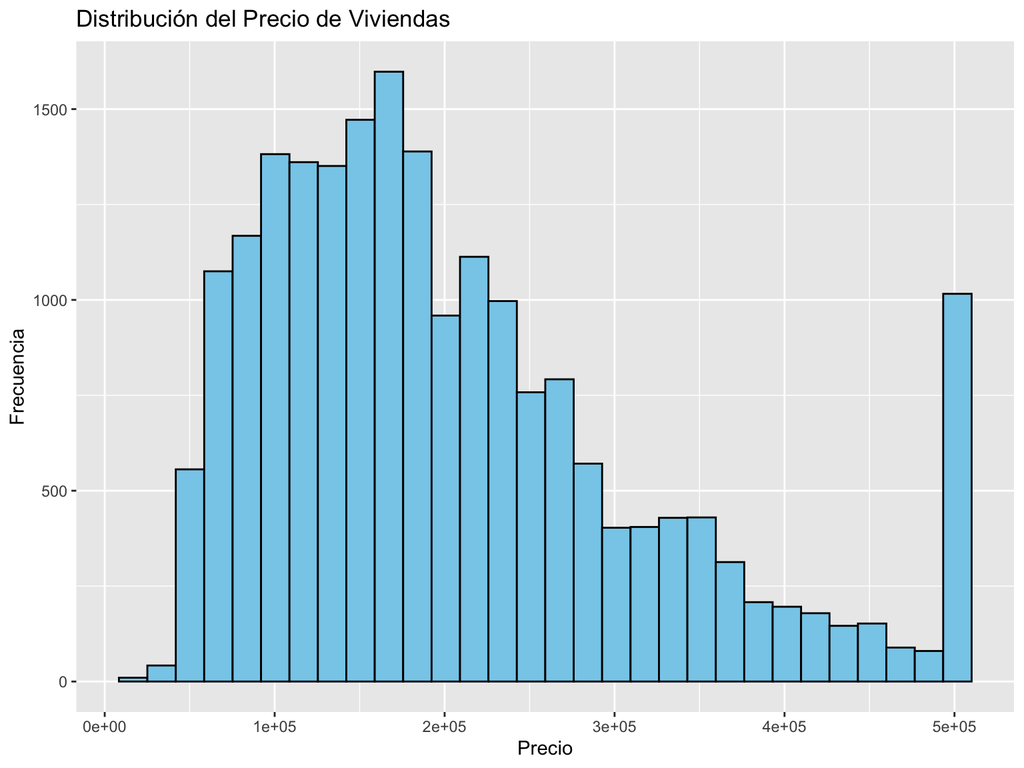

```r
# Histograma de precios para analizar la distribución
ggplot(df, aes(x = median_house_value)) +
  geom_histogram(fill="skyblue", color="black", bins=30) +
  labs(title="Distribución del Precio de Viviendas", x="Precio", y="Frecuencia")
```

*Comentario:* Se observa que el precio de las viviendas tiene una distribución sesgada a la derecha, con un límite superior en $500,000.

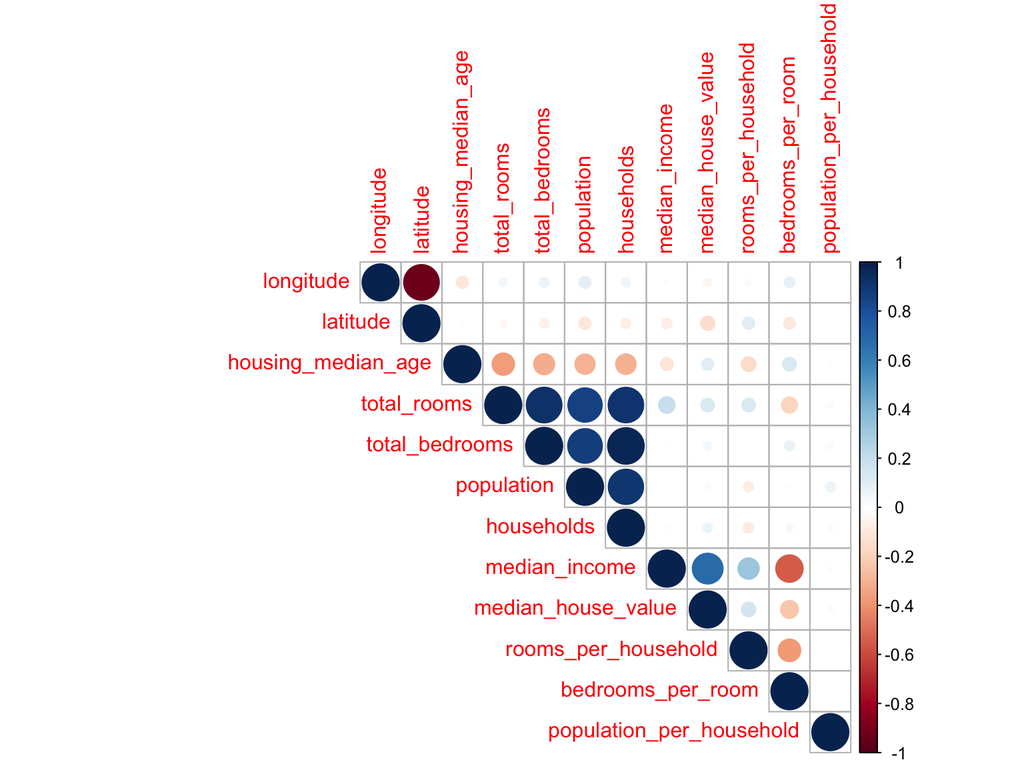

```r
# Matriz de correlación para analizar relaciones entre variables
num_vars <- df %>% select(where(is.numeric))
corr_matrix <- cor(num_vars)
corrplot(corr_matrix, method="circle", type="upper")
```

*Comentario:* La matriz de correlación ayuda a identificar relaciones lineales entre variables. Se espera que `median_income` tenga una fuerte correlación con el precio.

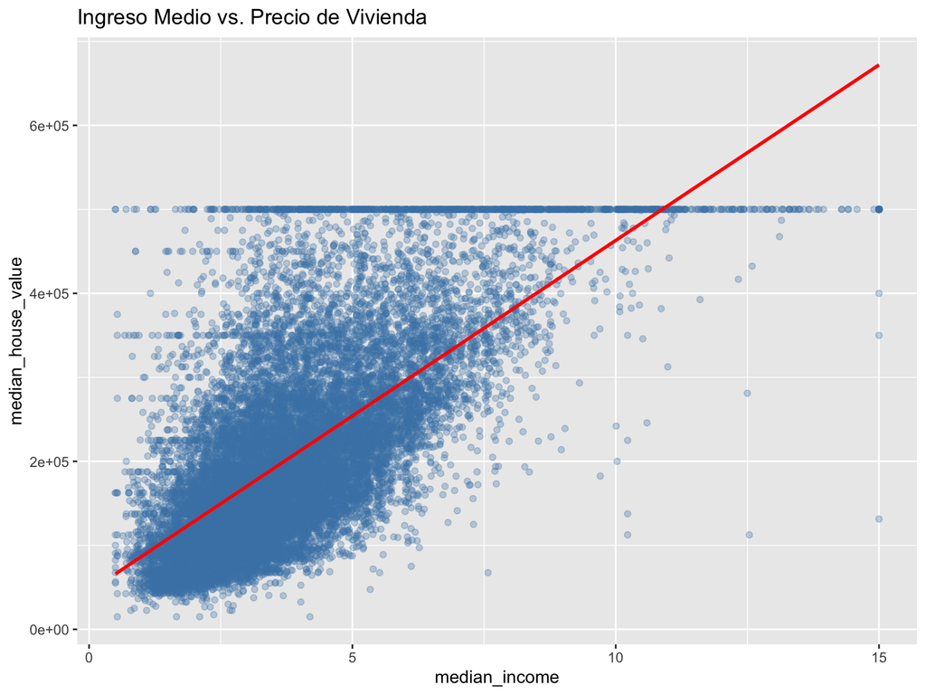

```r
# Relación entre ingreso y precio de vivienda
ggplot(df, aes(x = median_income, y = median_house_value)) +
  geom_point(alpha=0.3, color="steelblue") +
  geom_smooth(method="lm", se=FALSE, color="red") +
  labs(title="Ingreso Medio vs. Precio de Vivienda")
```

*Comentario:* Se confirma una relación positiva entre ingreso medio y precio de vivienda, con una tendencia lineal clara.